# Strings and factors

# String manipulation

Instead of putting things into dataframes, just put things into vectors for simpler examples of how strings are manipulated

Use `str_detect()` to find specific matches in strings, passing it the string vector first and then the pattern to match afterwards Returns logical vector based on whether the pattern was found per element of your vector, e.g. checking for “a” returns FALSE TRUE FALSE FALSE since only “name” has “a” Note that string functions are **case sensitive** - must match pattern exactly, including capitalization `str_replace()` to replace a specified pattern with another pattern Note that default behavior of `str_replace()` is to change only the first instance, not all other instances

```r
str_replace(string_vec, "i", "I")
```

```
[1] "my"      "name"    "Is"      "skIbidi"
```

These are great, but we have exact matches for short patterns, basically 1 letter long. What if we have more complicated strings? Maybe you want to find a specific pattern, like starts with or ends with “i think” This is where regex becomes useful `^` indicates **beginning of a line**, so `"^i think"` returns TRUE TRUE TRUE FALSE and `$` indicates **ending of a line**, so `"i think$"` returns FALSE FALSE FALSE TRUE To allow for multiple options, use `[]` and then your options in the brackets, e.g. `[Pp]` accounts for either uppercase or lowercase p in that slot

```r
str_detect(string_vec,"[Pp]umpkin")
```

```
[1]  TRUE  TRUE  TRUE FALSE
```

Can also use `[0-9]` to get all numbers from 0-9 e.g. looking for `"^[0-9][a-z]"` searches for strings that start with any number between 0-9 and then any letter a-z (lowercase) at the beginning of the string

```r
str_detect(string_vec, "^[0-9][a-z]")
```

```
[1]  TRUE  TRUE FALSE FALSE
```

What is a wildcard that will match any character? `.` matches any specific character

```r
str_detect(string_vec, "7.11")
```

```
[1]  TRUE  TRUE FALSE  TRUE
```

Now when things get really weird What if we want to find `{}` but we don’t mean for `[]` to be a catchall for the given characters we supply it - i.e. how do we **find special characters?** `str_detect` with `"["` will return error since it is reading `[` as the special character, which is expecting a closing bracket Need to break with `\\`, which is `\` but `\` is a special character, so we need to denote what we intend for `\` with `\\` to distinguish it from its special character use Remember that you can look up basic pattern matching online

```r
str_detect(string_vec, "\\[")
```

```
[1]  TRUE FALSE  TRUE  TRUE
```

# Factors

```r
sex_vec |>
  as.numeric()
```

```
[1] 2 2 1 1
```

To relevel factors, use `fct_relevel` and then pass it your specified levels or if only two levels, what the first level should be and it will implicitly set the second level

This is where you can get in problems with factors - underlying structure is entirely different based on ordering which will show up in plots, tables, regression, leading to unexpected output or results **Automatically recode/set the factor levels when initializing a factor variable so that you can keep track of what is going on throughout your analysis pipeline** All functions in `stringr` package start with `str`, including `str_dup` to duplicate strings, `str_length` to get length of strings, `str_remove` which is similar to `str_replace` but replaces pattern with a space Can put things in order of frequency

# NSDUH

This is the data we worked on last lecture from the NSDUH study We can read the table as HTML and use string and factor functions on it `slice(-1)` is because we want to remove the first row, which is the encoding information

We have variables for 12+, and 12-17 - 2013-2014 (percents), 2014-2015 (percents), and p value Let’s say we don’t want p value so we can get rid of those We need to tidy up the data a bit and separate these variables into age, year, and their corresponding percent You may notice that all of these variables are actually set to character since having a single character, as some of these percents have, will override any numeric observations and set the variable as character

So our plan: - get rid of p values - pivot longer - convert to numeric

Plotting the data for just 12-17 yos Maybe we want to order states in order of their percents so that trends are clearer - `fct_reorder(State, percent)`

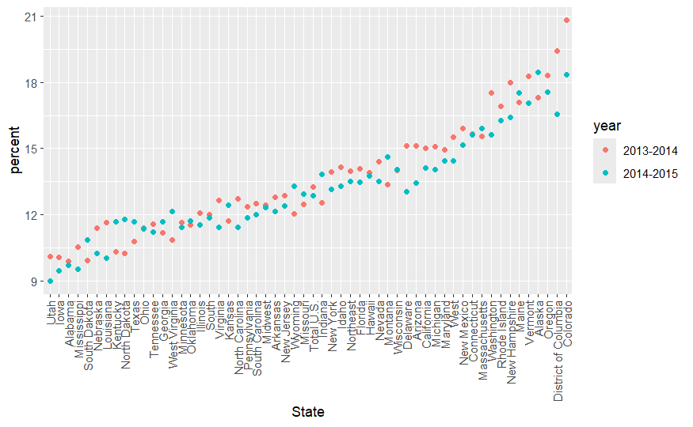

# NYC restaurant inspections

Data includes things like inspection dates (some of which don’t make sense), violation code, violation descriptions We can get counts of each grade per borough, using `count` and passing it `boro` and `grade` Then we can pivot this data wider to have a column for each grade

We can filter data to only get those with A-C grades and without missing boroughs Then we can use string functions to look for pizza spots Before doing so, want to mutate `dba` to a sentence using `str_to_sentence` Then we can do a quick bar plot of borough and counts of pizza spots with inspections All this to show that with a categorical variable like borough, it will set it to alphabetical order by default We can change this by `mutate` and `fct_infreq`, e.g. reorder in order of frequency using `fct_infreq(boro)`, or by `mutate` and `fct_relevel` and specify a specific vector of levels

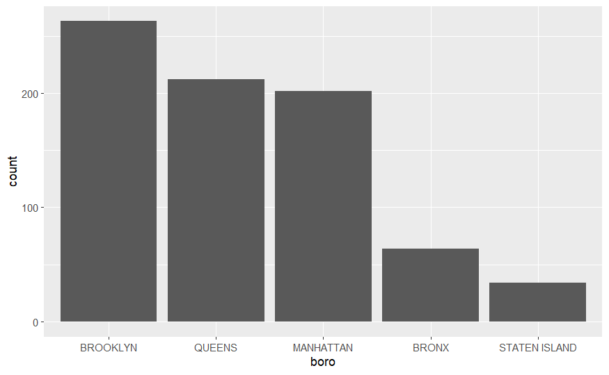

How can things go wrong?

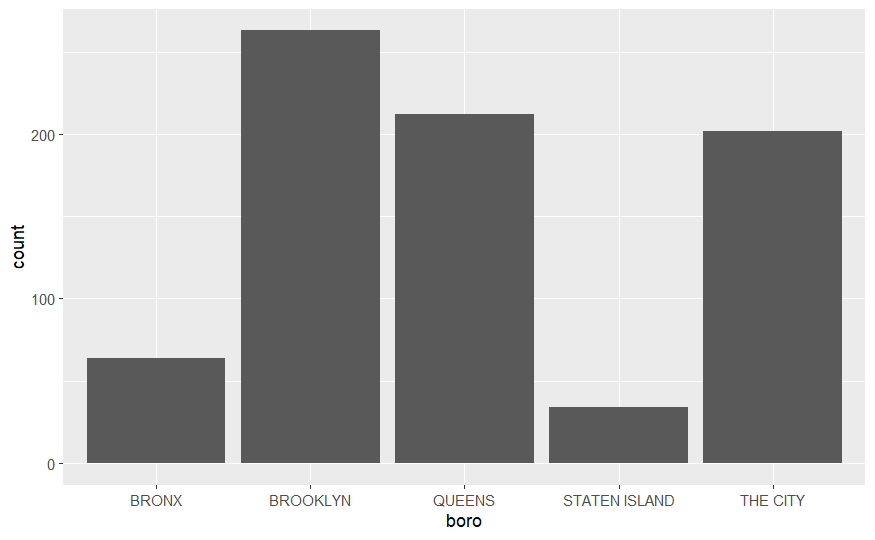

In this example, we would expect the borough frequency to be maintained However, once we mutate with `str_replace` right after, it resets the factor levels to be in alphabetical order again Below code will work, doing it all in one step

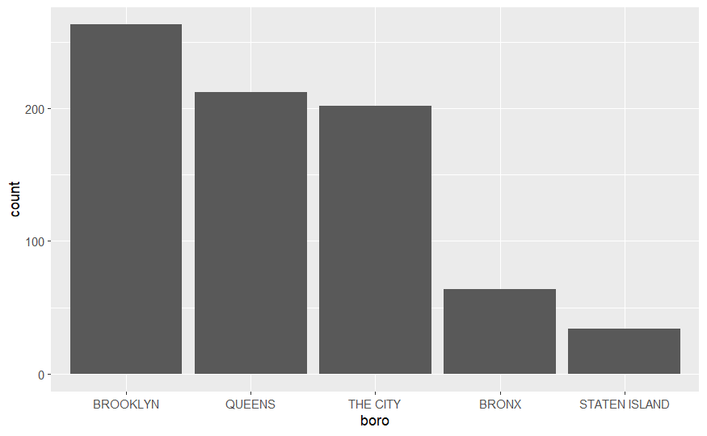

Note that below is a nonsensical regression model, just to show behaviors in factors This gives 4 parameter estimates, implicitly defining a categorical variable with **THE BRONX AS THE REFERENCE GROUP** and **ASSUMING ALPHABETICAL ORDER, TOOK THE FIRST ONE AS THE REFERENCE GROUP**

```r
rest_inspec |>
  mutate(dba = str_to_sentence(dba)) |>
  filter(str_detect(dba, "Pizza")) |>
  lm(zipcode ~ boro, data = _)
```

```
Call:
lm(formula = zipcode ~ boro, data = filter(mutate(rest_inspec,
    dba = str_to_sentence(dba)), str_detect(dba, "Pizza")))

Coefficients:
      (Intercept)       boroBROOKLYN      boroMANHATTAN         boroQUEENS  boroSTATEN ISLAND
          10461.2              761.2             -435.7              909.1             -150.9
```

# Midterm

Make private repository and add bst-p8105 GitHub user to repository Do same kinds of stuff you would do elsewhere - make repository, set rest of it up Strict word limit of 500 words Use `wordcountaddin::word_count("midterm.Rmd")` to get the word count Render to GitHub document as before Import Zillow dataset, make sure you can import, quality control, exploratory data analysis, and data visualization